# Deep Learning

```
shuffled test set:
imgIx: 3314: label: F
```

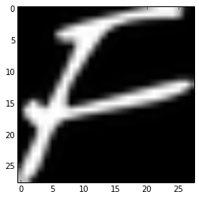

```
imgIx: 9589: label: H
```

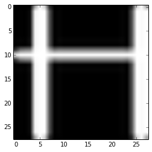

```
imgIx: 9076: label: I
```

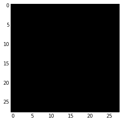

```
imgIx: 13263: label: J
```

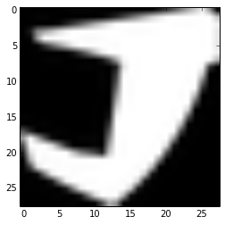

```
imgIx: 12525: label: I
```

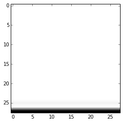

```
imgIx: 5487: label: H
```

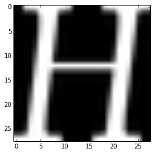

```
imgIx: 4938: label: D
```

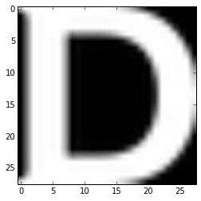

```
imgIx: 9850: label: B
```

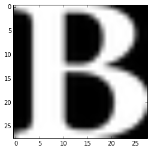

```
imgIx: 9399: label: E
```

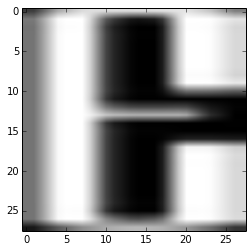

```
imgIx: 18484: label: G
```

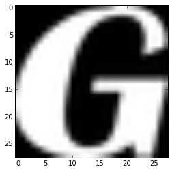

```python
print 'shuffled test set:'
imgIxLst = np.random.random_integers(0, test_dataset.shape[0] - 1, 10)
for imgIx in imgIxLst:
    print 'imgIx: %d: label: %s' % (imgIx, dspLabels[test_labels[imgIx]])
    plt.figure
    plt.imshow(test_dataset[imgIx,:,:], cmap = plt.cm.gray)
    plt.show()
```

## Problem 4

Another check: we expect the data to be balanced across classes. Verify that.

```python
#print type(train_labels); print train_labels.shape; print train_labels[0:10]
print np.sum(train_labels == 0)
print np.unique(train_labels)
print 'train labels freqs: %s' % \
    ([np.sum(train_labels == thsLabel) for thsLabel in np.unique(train_labels)])
```

```
52909
[0 1 2 3 4 5 6 7 8 9]
train labels freqs: [52909, 52911, 52912, 52911, 52912, 52912, 52912, 52912, 52912, 52911]
```

```python
test_labels_freqs = {}
for thsLabel in np.unique(test_labels):
    test_labels_freqs[thsLabel] = np.sum(test_labels == thsLabel)
print 'test labels freqs: %s' % (test_labels_freqs)
```

```
test labels freqs: {0: 1872, 1: 1873, 2: 1873, 3: 1873, 4: 1873, 5: 1872, 6: 1872, 7: 1872, 8: 1872, 9: 1872}
```

Prune the training data as needed. Depending on your computer setup, you might not be able to fit it all in memory, and you can tune train_size as needed.

Also create a validation dataset for hyperparameter tuning.

```python
train_size = train_dataset.shape[0]
#train_size = 200000
valid_size = 10000

valid_dataset = train_dataset[:valid_size,:,:]
valid_labels = train_labels[:valid_size]
train_dataset = train_dataset[valid_size:valid_size+train_size,:,:]
train_labels = train_labels[valid_size:valid_size+train_size]
print('Training', train_dataset.shape, train_labels.shape)
print('Validation', valid_dataset.shape, valid_labels.shape)
```

```
('Training', (519114, 28, 28), (519114,))
('Validation', (10000, 28, 28), (10000,))
```

Finally, let's save the data for later reuse:

```python
pickle_file = os.getcwd() + '/data/notMNIST.pickle'
print pickle_file
```

```
/Users/bbalaji-2012/Documents/Work/Courses/Udacity/DeepLearning/code/tensorflow/examples/udacity/data/notMNIST.pickle
```

```python
#pickle_file = 'notMNIST.pickle'

try:
  f = open(pickle_file, 'wb')
  save = {
    'train_dataset': train_dataset,
    'train_labels': train_labels,
    'valid_dataset': valid_dataset,
    'valid_labels': valid_labels,
    'test_dataset': test_dataset,
    'test_labels': test_labels,
    }
  pickle.dump(save, f, pickle.HIGHEST_PROTOCOL)
  f.close()
except Exception as e:
  print('Unable to save data to', pickle_file, ':', e)
  raise
```

```python
statinfo = os.stat(pickle_file)
print('Compressed pickle size:', statinfo.st_size)
```

```
('Compressed pickle size:', 1720211761)
```

## Problem 5

By construction, this dataset might contain a lot of overlapping samples, including training data that's also contained in the validation and test set! Overlap between training and test can skew the results if you expect to use your model in an environment where there is never an overlap, but are actually ok if you expect to see training samples recur when you use it. Measure how much overlap there is between training, validation and test samples.

Optional questions:

- What about near duplicates between datasets? (images that are almost identical)
- Create a sanitized validation and test set, and compare your accuracy on those in subsequent assignments.

```python
# print train_dataset[0:3]
# print np.ascontiguousarray(train_dataset[0:3])
# print np.ascontiguousarray(train_dataset[0:3]).shape
```

```python
#print train_dataset[0:3]
trainSet = set(img.tostring() for img in train_dataset)
print 'train: shape: %s vs. len(set): %d pctDups: %0.4f' % \
    (train_dataset.shape, len(trainSet), \
     (train_dataset.shape[0] * 1.0 / len(trainSet) - 1) * 100)

validSet = set(img.tostring() for img in valid_dataset)
print 'valid: shape: %s vs. len(set): %d pctDups: %0.4f' % \
    (valid_dataset.shape, len(validSet), \
     (valid_dataset.shape[0] * 1.0 / len(validSet) - 1) * 100)

testSet = set(img.tostring() for img in test_dataset)
print 'test : shape: %s vs. len(set): %d pctDups: %0.4f' % \
    (test_dataset.shape, len(testSet), \
     (test_dataset.shape[0] * 1.0 / len(testSet) - 1) * 100)
```

```
train: shape: (519114, 28, 28) vs. len(set): 454064 pctDups: 14.3262
valid: shape: (10000, 28, 28) vs. len(set): 9843 pctDups: 1.5950
test : shape: (18724, 28, 28) vs. len(set): 18232 pctDups: 2.6986
```

```python
print 'valid set overlap with train set: %0.4f' % \
    (len(validSet.intersection(trainSet)) * 1.0 / len(validSet))
print ' test set overlap with train set: %0.4f' % \
    (len( testSet.intersection(trainSet)) * 1.0 / len( testSet))
print 'valid set overlap with  test set: %0.4f' % \
    (len(validSet.intersection( testSet)) * 1.0 / len(validSet))
```

```
valid set overlap with train set: 0.1992
 test set overlap with train set: 0.2473
valid set overlap with  test set: 0.0131
```

## Problem 6

Let's get an idea of what an off-the-shelf classifier can give you on this data. It's always good to check that there is something to learn, and that it's a problem that is not so trivial that a canned solution solves it.

Train a simple model on this data using 50, 100, 1000 and 5000 training samples. Hint: you can use the LogisticRegression model from sklearn.linear_model.

Optional question: train an off-the-shelf model on all the data!

```python
# import graphlab
# print graphlab.version
# graphlab.canvas.set_target('ipynb')
```

[output not shown]

```python
# graphlab.logistic_classifier.create(image_train,target='label',
#                                               features=['image_array'])
```

```python
print train_dataset[0:3,:,:]
print np.reshape(train_dataset[0:3,:,:], (3, train_dataset.shape[1] * train_dataset.shape[2]))
print np.reshape(train_dataset[0:3,:,:], (3, train_dataset.shape[1] * train_dataset.shape[2])).shape
```

[output not shown]

```python
from sklearn import metrics, linear_model
import pandas as pd
```

```python
def fitMdl(nFitObs = 50):
    mdl = linear_model.LogisticRegression(verbose = 1)
    mdl.fit(np.reshape(train_dataset[0:nFitObs,:,:], \
                            (nFitObs, train_dataset.shape[1] * train_dataset.shape[2])), \
                 train_labels[0:nFitObs])
    print mdl.get_params()
    print mdl.coef_.shape
    print '  coeff stats:'
    for lblIx in xrange(len(dspLabels)):
        print '  label:%s; minCoeff:row:%2d, col:%2d, value:%0.4f; maxCoeff:row:%2d, col:%2d, value:%0.4f;' % \
            (dspLabels[lblIx], \
             mdl.coef_[lblIx,:].argmin() / image_size, \
             mdl.coef_[lblIx,:].argmin() % image_size, \
             mdl.coef_[lblIx,:].min(), \
             mdl.coef_[lblIx,:].argmax() / image_size, \
             mdl.coef_[lblIx,:].argmax() % image_size, \
             mdl.coef_[lblIx,:].max())

    train_pred_labels = mdl.predict(np.reshape(train_dataset[0:nFitObs,:,:], \
                                                    (nFitObs               , image_size ** 2)))
    accuracy_train = metrics.accuracy_score(train_pred_labels, train_labels[0:nFitObs])
    print '  accuracy train:%0.4f' % (accuracy_train)
    print metrics.confusion_matrix(train_labels[0:nFitObs], train_pred_labels)

    valid_pred_labels = mdl.predict(np.reshape(valid_dataset, \
                                                    (valid_dataset.shape[0], image_size ** 2)))
    accuracy_valid = metrics.accuracy_score(valid_pred_labels, valid_labels)
    print '  accuracy valid:%0.4f' % (accuracy_valid)
    print metrics.confusion_matrix(valid_labels           , valid_pred_labels)

    test_pred_labels  = mdl.predict(np.reshape(test_dataset, \
                                                    (test_dataset.shape[0], image_size ** 2)))
    accuracy_test = metrics.accuracy_score( test_pred_labels,  test_labels)
    print '  accuracy  test:%0.4f' % (accuracy_test)
    test_conf = pd.DataFrame(metrics.confusion_matrix( test_labels,  test_pred_labels), \
                             index = dspLabels, columns = dspLabels)
    print test_conf

    return(mdl, (accuracy_train, accuracy_valid, accuracy_test))
```

```python
mdl50 = fitMdl(nFitObs = 50)
```

```
[LibLinear]{'warm_start': False, 'C': 1.0, 'n_jobs': 1, 'verbose': 1, 'intercept_scaling': 1, 'fit_intercept': True, 'max_iter': 100, 'penalty': 'l2', 'multi_class': 'ovr', 'random_state': None, 'dual': False, 'tol': 0.0001, 'solver': 'liblinear', 'class_weight': None}
(10, 784)
  coeff stats:
  label:A; minCoeff:row:26, col: 8, value:-0.2571; maxCoeff:row:24, col:25, value:0.1487;
  label:B; minCoeff:row: 2, col:20, value:-0.2250; maxCoeff:row:16, col:23, value:0.2356;
  label:C; minCoeff:row:26, col: 4, value:-0.2084; maxCoeff:row:25, col:26, value:0.2056;
  label:D; minCoeff:row:25, col: 7, value:-0.1682; maxCoeff:row: 9, col:25, value:0.1925;
  label:E; minCoeff:row: 1, col:19, value:-0.1914; maxCoeff:row:25, col:27, value:0.2057;
  label:F; minCoeff:row: 1, col:19, value:-0.1759; maxCoeff:row: 2, col: 1, value:0.2158;
  label:G; minCoeff:row: 1, col:19, value:-0.2289; maxCoeff:row:11, col: 0, value:0.1832;
  label:H; minCoeff:row:26, col: 9, value:-0.2210; maxCoeff:row:27, col:27, value:0.1907;
  label:I; minCoeff:row: 0, col:14, value:-0.1343; maxCoeff:row:27, col:27, value:0.2123;
  label:J; minCoeff:row:13, col: 9, value:-0.1960; maxCoeff:row: 0, col:21, value:0.1679;
  accuracy train:1.0000
[[5 0 0 0 0 0 0 0 0 0]
 [0 6 0 0 0 0 0 0 0 0]
 [0 0 4 0 0 0 0 0 0 0]
 [0 0 0 4 0 0 0 0 0 0]
 [0 0 0 0 6 0 0 0 0 0]
 [0 0 0 0 0 4 0 0 0 0]
 [0 0 0 0 0 0 6 0 0 0]
 [0 0 0 0 0 0 0 2 0 0]
 [0 0 0 0 0 0 0 0 4 0]
 [0 0 0 0 0 0 0 0 0 9]]
  accuracy valid:0.5822
[[682  27   6  28  28  18  33  59  31 121]
 [ 24 671  18  48  33  21  73  14  63  49]
 [ 37  39 574  35 161   2 102   1  28  29]
 [ 24  53  16 698  14  21  60   5  31  63]
 [ 51 215 118  13 377   9  36   8  84  45]
 [ 55 173  17  18 168 437  21   4  16  53]
 [ 43  46 216  37  60  20 513   3  20  80]
 [ 79 101   8  30  90 160  37 385  50  35]
 [ 47  20  38  10  60   7  32   7 625 188]
 [ 26  11   9  16  17  16  26   1  13 860]]
  accuracy  test:0.6381
      A     B     C     D    E    F     G    H     I     J
A  1283    43     9    34   33   40    42  103    34   251
B    38  1448    19    65   41   23    73   16    77    73
C    27    65  1241    53  271    5   137    1    44    29
D    24    92    32  1474   25   30    68    5    43    80
E    46   495   210    14  818   15    43   13   175    44
F    93   371    16    22  302  919    25    9    29    86
G    67    61   417    60   76   16  1015    6    37   117
H   144   182    18    39  206  241    44  793   154    51
I    33    21    36    20  122   16    26   10  1223   365
J    19     9    13    22   21   15    16    1    22  1734
```

```python
models = pd.DataFrame({'nFitObs': [1e2, 1e3, 1e4, 1e5, train_dataset.shape[0]]})
models = models.set_index(models['nFitObs'])
models['mdl'] = linear_model.LogisticRegression()
models['accuracy.fit'] = -1; models['accuracy.vld'] = -1; models['accuracy.new'] = -1

for thsN in models['nFitObs']:
    models.ix[thsN, 'mdl'], (models.ix[thsN, 'accuracy.fit'], \
                             models.ix[thsN, 'accuracy.vld'], \
                             models.ix[thsN, 'accuracy.new'], \
                            ) = fitMdl(nFitObs = thsN)

print models
```

```
[LibLinear]{'warm_start': False, 'C': 1.0, 'n_jobs': 1, 'verbose': 1, 'intercept_scaling': 1, 'fit_intercept': True, 'max_iter': 100, 'penalty': 'l2', 'multi_class': 'ovr', 'random_state': None, 'dual': False, 'tol': 0.0001, 'solver': 'liblinear', 'class_weight': None}
```

```
(10, 784)
  coeff stats:
  label:A; minCoeff:row:26, col: 8, value:-0.3014; maxCoeff:row:17, col:17, value:0.2229;
  label:B; minCoeff:row: 1, col:19, value:-0.2240; maxCoeff:row:16, col:23, value:0.3035;
  label:C; minCoeff:row:26, col: 8, value:-0.2396; maxCoeff:row:25, col:15, value:0.1714;
  label:D; minCoeff:row:14, col:19, value:-0.2523; maxCoeff:row:27, col: 1, value:0.2116;
  label:E; minCoeff:row: 9, col:19, value:-0.2736; maxCoeff:row:11, col:11, value:0.2807;
  label:F; minCoeff:row:26, col:19, value:-0.3569; maxCoeff:row: 2, col: 2, value:0.2562;
  label:G; minCoeff:row: 1, col:19, value:-0.2610; maxCoeff:row:18, col:27, value:0.2457;
  label:H; minCoeff:row:26, col:10, value:-0.2259; maxCoeff:row: 0, col:27, value:0.1947;
  label:I; minCoeff:row:15, col:18, value:-0.2584; maxCoeff:row:27, col:27, value:0.2571;
  label:J; minCoeff:row:24, col: 5, value:-0.2323; maxCoeff:row: 0, col:27, value:0.2230;
  accuracy train:1.0000
[[11  0  0  0  0  0  0  0  0  0]
 [ 0  9  0  0  0  0  0  0  0  0]
 [ 0  0  9  0  0  0  0  0  0  0]
 [ 0  0  0  6  0  0  0  0  0  0]
 [ 0  0  0  0 16  0  0  0  0  0]
 [ 0  0  0  0  0  9  0  0  0  0]
 [ 0  0  0  0  0  0 12  0  0  0]
 [ 0  0  0  0  0  0  0  6  0  0]
 [ 0  0  0  0  0  0  0  0 10  0]
 [ 0  0  0  0  0  0  0  0  0 12]]
  accuracy valid:0.6829
[[728  26  10  17  45  13  45  39  22  88]
 [ 23 692  14  42  67  24  49  20  51  32]
 [ 16  22 699  13 128   6  70   6  20  28]
 [ 16  54  20 694  32  23  38  22  27  59]
 [ 18  24  78   4 606  52  25  36  76  37]
 [ 13  13  17   2 161 671  16   9  18  42]
 [ 20  28  93  17  53  21 733   5  20  48]
 [ 57  44  10  23 118 115  34 516  30  28]
 [ 30  10  31   7  85  24  27  13 651 156]
 [ 18   7  13  16  27  23  27   4  21 839]]
  accuracy  test:0.7498
      A     B     C     D     E     F     G     H     I     J
A  1382    33     7    22    46    41    61    50    26   204
B    31  1485    18    44    84    28    41    14    65    63
C     4    38  1484    15   152     6   119     6    28    21
D    17    72    28  1502    35    38    47    14    36    84
```

[output cut: 194 more lines]

```
         nFitObs                                                mdl  \
nFitObs
100          100  LogisticRegression(C=1.0, class_weight=None, d...
1000        1000  LogisticRegression(C=1.0, class_weight=None, d...
10000      10000  LogisticRegression(C=1.0, class_weight=None, d...
100000    100000  LogisticRegression(C=1.0, class_weight=None, d...
519114    519114  LogisticRegression(C=1.0, class_weight=None, d...

         accuracy.fit  accuracy.vld  accuracy.new
nFitObs
100          1.000000        0.6829      0.749786
1000         0.995000        0.7580      0.834223
10000        0.898300        0.7892      0.860233
100000       0.834390        0.8206      0.889126
519114       0.829508        0.8252      0.893826
```

```python
print [nObs * 1.0 / train_dataset.shape[0] for nObs in [1e2, 1e3, 1e4, 1e5, 1e6]]
```

```
[0.0001926359142693127, 0.0019263591426931272, 0.01926359142693127, 0.1926359142693127, 1.9263591426931272]
```

```python
mdl500 = fitMdl(nFitObs = 500)
```

```
[LibLinear]{'warm_start': False, 'C': 1.0, 'n_jobs': 1, 'verbose': 1, 'intercept_scaling': 1, 'fit_intercept': True, 'max_iter': 100, 'penalty': 'l2', 'multi_class': 'ovr', 'random_state': None, 'dual': False, 'tol': 0.0001, 'solver': 'liblinear', 'class_weight': None}
(10, 784)
  coeff stats:
  label:A; minCoeff:row:21, col: 9, value:-0.3856; maxCoeff:row:25, col:23, value:0.3815;
  label:B; minCoeff:row:14, col:26, value:-0.5882; maxCoeff:row:17, col:24, value:0.4130;
  label:C; minCoeff:row:27, col: 1, value:-0.5348; maxCoeff:row: 6, col: 6, value:0.3678;
  label:D; minCoeff:row: 0, col:26, value:-0.6628; maxCoeff:row:15, col:27, value:0.3062;
  label:E; minCoeff:row: 2, col:13, value:-0.6107; maxCoeff:row:10, col:11, value:0.6330;
  label:F; minCoeff:row:15, col:18, value:-0.3733; maxCoeff:row: 1, col:27, value:0.4033;
  label:G; minCoeff:row:15, col:11, value:-0.5434; maxCoeff:row:18, col:24, value:0.4875;
  label:H; minCoeff:row: 0, col:15, value:-0.5604; maxCoeff:row: 0, col:27, value:0.6619;
  label:I; minCoeff:row:15, col:18, value:-0.5818; maxCoeff:row:24, col: 2, value:0.7166;
  label:J; minCoeff:row:23, col: 6, value:-0.6128; maxCoeff:row: 0, col:27, value:0.7012;
  accuracy train:1.0000
[[56  0  0  0  0  0  0  0  0  0]
 [ 0 45  0  0  0  0  0  0  0  0]
 [ 0  0 51  0  0  0  0  0  0  0]
 [ 0  0  0 42  0  0  0  0  0  0]
 [ 0  0  0  0 54  0  0  0  0  0]
 [ 0  0  0  0  0 43  0  0  0  0]
 [ 0  0  0  0  0  0 59  0  0  0]
 [ 0  0  0  0  0  0  0 42  0  0]
 [ 0  0  0  0  0  0  0  0 48  0]
 [ 0  0  0  0  0  0  0  0  0 60]]
  accuracy valid:0.7396
[[790  13  10  25  23  22  25  32  35  58]
 [ 29 704  15  61  39  23  44  19  40  40]
 [ 11  19 753  14  43  15  76  11  22  44]
 [ 24  22  20 756  19  20  30   9  37  48]
 [ 21  55  76  11 605  39  24  24  63  38]
 [ 14  18  19   5  43 766  15   8  27  47]
 [ 20  22  61  20  35  26 748   8  22  76]
 [ 41  12   7  20  31  50  19 716  19  60]
 [ 16  12  18   9  39  25  33  19 722 141]
 [ 16   7  11  15  15  26  31  13  25 836]]
  accuracy  test:0.8161
      A     B     C     D     E     F     G     H     I     J
A  1512    14    14    33    26    37    52    44    36   104
B    41  1489    24    64    43    26    53    28    48    57
C     8    21  1598    11    59    15    92     6    18    45
D    28    28    23  1605    27    20    30     7    43    62
E    15   164   100    11  1301    63    34    41    98    46
F    15    20    15    19    48  1644     4    11    27    69
G    29    24   115    16    38    24  1502     4    30    90
H    64    16    20    16    40    74    23  1498    36    85
I    27    12    28     8    45    32    36    22  1422   240
J    13     8    14    14     9    31    24     7    42  1710
```

```python
nFitObs = 50
mdl = linear_model.LogisticRegression(verbose = 1)
mdl.fit(np.reshape(train_dataset[0:nFitObs,:,:], \
                        (nFitObs, train_dataset.shape[1] * train_dataset.shape[2])), \
             train_labels[0:nFitObs])
print mdl.get_params()
print mdl.coef_.shape
print '  coeff stats:'
for lblIx in xrange(len(dspLabels)):
    print '  label:%s; minCoeff:row:%2d, col:%2d, value:%0.4f; maxCoeff:row:%2d, col:%2d, value:%0.4f;' % \
        (dspLabels[lblIx], \
         mdl.coef_[lblIx,:].argmin() / image_size, \
         mdl.coef_[lblIx,:].argmin() % image_size, \
         mdl.coef_[lblIx,:].min(), \
         mdl.coef_[lblIx,:].argmax() / image_size, \
         mdl.coef_[lblIx,:].argmax() % image_size, \
         mdl.coef_[lblIx,:].max())

train_pred_labels = mdl.predict(np.reshape(train_dataset[0:nFitObs,:,:], \
                                                (nFitObs               , image_size ** 2)))
print '  accuracy train:%0.4f' % \
    (metrics.accuracy_score(train_pred_labels, train_labels[0:nFitObs]))
print metrics.confusion_matrix(train_labels[0:nFitObs], train_pred_labels)

valid_pred_labels = mdl.predict(np.reshape(valid_dataset, \
                                                (valid_dataset.shape[0], image_size ** 2)))
print '  accuracy valid:%0.4f' % \
    (metrics.accuracy_score(valid_pred_labels, valid_labels))
print metrics.confusion_matrix(valid_labels           , valid_pred_labels)

test_pred_labels  = mdl.predict(np.reshape(test_dataset, \
                                                (test_dataset.shape[0], image_size ** 2)))
print '  accuracy  test:%0.4f' % \
    (metrics.accuracy_score( test_pred_labels,  test_labels))
test_conf = pd.DataFrame(metrics.confusion_matrix( test_labels,  test_pred_labels), \
                         index = dspLabels, columns = dspLabels)
print test_conf
```

```
[LibLinear]{'warm_start': False, 'C': 1.0, 'n_jobs': 1, 'verbose': 1, 'intercept_scaling': 1, 'fit_intercept': True, 'max_iter': 100, 'penalty': 'l2', 'multi_class': 'ovr', 'random_state': None, 'dual': False, 'tol': 0.0001, 'solver': 'liblinear', 'class_weight': None}
(10, 784)
  coeff stats:
  label:A; minCoeff:row:26, col: 8, value:-0.2571; maxCoeff:row:24, col:25, value:0.1487;
  label:B; minCoeff:row: 2, col:20, value:-0.2250; maxCoeff:row:16, col:23, value:0.2356;
  label:C; minCoeff:row:26, col: 4, value:-0.2084; maxCoeff:row:25, col:26, value:0.2056;
  label:D; minCoeff:row:25, col: 7, value:-0.1682; maxCoeff:row: 9, col:25, value:0.1925;
  label:E; minCoeff:row: 1, col:19, value:-0.1914; maxCoeff:row:25, col:27, value:0.2057;
  label:F; minCoeff:row: 1, col:19, value:-0.1759; maxCoeff:row: 2, col: 1, value:0.2158;
  label:G; minCoeff:row: 1, col:19, value:-0.2289; maxCoeff:row:11, col: 0, value:0.1832;
  label:H; minCoeff:row:26, col: 9, value:-0.2210; maxCoeff:row:27, col:27, value:0.1907;
  label:I; minCoeff:row: 0, col:14, value:-0.1343; maxCoeff:row:27, col:27, value:0.2123;
  label:J; minCoeff:row:13, col: 9, value:-0.1960; maxCoeff:row: 0, col:21, value:0.1679;
  accuracy train:1.0000
[[5 0 0 0 0 0 0 0 0 0]
 [0 6 0 0 0 0 0 0 0 0]
 [0 0 4 0 0 0 0 0 0 0]
 [0 0 0 4 0 0 0 0 0 0]
 [0 0 0 0 6 0 0 0 0 0]
 [0 0 0 0 0 4 0 0 0 0]
 [0 0 0 0 0 0 6 0 0 0]
 [0 0 0 0 0 0 0 2 0 0]
 [0 0 0 0 0 0 0 0 4 0]
 [0 0 0 0 0 0 0 0 0 9]]
  accuracy valid:0.5822
[[682  27   6  28  28  18  33  59  31 121]
 [ 24 671  18  48  33  21  73  14  63  49]
 [ 37  39 574  35 161   2 102   1  28  29]
 [ 24  53  16 698  14  21  60   5  31  63]
 [ 51 215 118  13 377   9  36   8  84  45]
 [ 55 173  17  18 168 437  21   4  16  53]
 [ 43  46 216  37  60  20 513   3  20  80]
 [ 79 101   8  30  90 160  37 385  50  35]
 [ 47  20  38  10  60   7  32   7 625 188]
 [ 26  11   9  16  17  16  26   1  13 860]]
  accuracy  test:0.6381
      A     B     C     D    E    F     G    H     I     J
A  1283    43     9    34   33   40    42  103    34   251
B    38  1448    19    65   41   23    73   16    77    73
C    27    65  1241    53  271    5   137    1    44    29
D    24    92    32  1474   25   30    68    5    43    80
E    46   495   210    14  818   15    43   13   175    44
F    93   371    16    22  302  919    25    9    29    86
G    67    61   417    60   76   16  1015    6    37   117
H   144   182    18    39  206  241    44  793   154    51
I    33    21    36    20  122   16    26   10  1223   365
J    19     9    13    22   21   15    16    1    22  1734
```

```python
print dspLabels
```

```
['A', 'B', 'C', 'D', 'E', 'F', 'G', 'H', 'I', 'J']
```

```python
print type(metrics.confusion_matrix( test_labels           ,  test_pred_labels))
```

```
<type 'numpy.ndarray'>
```

```python
import pandas as pd
```

[output not shown]

```python
test_conf = pd.DataFrame(metrics.confusion_matrix( test_labels           ,  test_pred_labels), \
                         index = dspLabels, columns = dspLabels)
print test_conf
```

```
      A     B     C     D    E    F     G    H     I     J
A  1283    43     9    34   33   40    42  103    34   251
B    38  1448    19    65   41   23    73   16    77    73
C    27    65  1241    53  271    5   137    1    44    29
D    24    92    32  1474   25   30    68    5    43    80
E    46   495   210    14  818   15    43   13   175    44
F    93   371    16    22  302  919    25    9    29    86
G    67    61   417    60   76   16  1015    6    37   117
H   144   182    18    39  206  241    44  793   154    51
I    33    21    36    20  122   16    26   10  1223   365
J    19     9    13    22   21   15    16    1    22  1734
```